# 13. SVM with R

FSD team

Tutorial ini adalah bagian dari mata kuliah Fundamen Sains Data, Informatika, UII. Pada Pertemuan 13, kita akan mencoba mengaplikasikan SVM ke dalam R Code.

### **I. When the data are linearly separable**

Pertama, kita akan mencoba SVM pada data dengan **dua kelas** yang dapat dipisahkan secara **linear**. Kali ini, *data set* yang akan digunakan, kita buat sendiri dengan fungsi membangkitkan bilangan secara **random** dan terdistribusi **normal**.

1. Sebelum bilangan random dibangkitkan, kita `set` dulu `seed`-nya. Tujuannya agar saat bilangan random tersebut kita bangkit lagi di lain waktu, kita mendapatkan bilangan yang sama dengan sebelumnya.

```r
set.seed(10111)
```

Nilai parameter di method `seed()` bebas, yang penting saat bilangan random tersebut kita bangkit lagi di lain waktu, nilai parameternya harus sama jika diinginkan mendapatkan bilangan yang sama dengan sebelumnya.

2. Empat puluh bilangan **random** yang terdistribusi **random** dibangkitkan menggunakan `rnorm()`. Bilangan-bilangan yang telah dibangkitkan tersebut akan dimasukkan ke dalam matrix dengan ukuran 20 baris dan 2 kolom.

```r
x <-  matrix(rnorm(40), 20, 2)
x
```

```
##             [,1]        [,2]
##  [1,]  0.4992207  0.83459057
##  [2,] -0.5095988  0.86535664
##  [3,] -0.3130123 -0.54000741
##  [4,]  0.7136758  0.09454017
##  [5,] -1.0506291 -0.49390571
##  [6,] -0.7504743  0.19165412
##  [7,] -0.3502830 -0.16827662
##  [8,]  0.6202636 -0.03877393
##  [9,] -0.2169360  0.03409674
## [10,] -0.2485535  0.68234694
## [11,]  0.3264276  0.40061717
## [12,] -0.3113315  0.38550956
## [13,]  1.7057305  0.52631182
## [14,]  1.3354574 -1.49779748
## [15,] -2.3406379  1.20544301
## [16,]  0.2445945 -1.18418390
## [17,] -0.2278119  0.53916368
## [18,] -1.3640324  1.32334502
## [19,]  0.6404738  0.17708567
## [20,] -2.0440209  0.95016425
```

Dua puluh baris dan 2 kolom merepresentasikan: *20 data point* atau *20 sampel* (banyaknya data) dengan *dua variabel* **x1** dan **x2**. Misal: **x1** adalah ukuran kadar gula darah seseorang dan **x2** adalah banyak gula yang dikonsumsi seseorang, yang nilainya telah dinormalisasi. Sehingga kita memiliki **data set** yang berukuran 20x2.

```r
y <-  factor(rep(c(-1, 1), c(10, 10)))
y
```

```
##  [1] -1 -1 -1 -1 -1 -1 -1 -1 -1 -1 1  1  1  1  1  1  1  1  1  1
## Levels: -1 1
```

Perintah `rep()` tersebut bisa juga ditulis `rep(c(-1, 1), each=10)`. Perintah `factor()` digunakan agar nilai (**+1**) dan (**-1**) menjadi kategori.

4. Variabel x1 dan x2 pada data set yang termasuk kelas y=1 ditambah 3.

```r
x[y == 1, ] <- x[y == 1, ] + 3
x
```

```
##             [,1]        [,2]
##  [1,]  0.4992207  0.83459057
##  [2,] -0.5095988  0.86535664
##  [3,] -0.3130123 -0.54000741
##  [4,]  0.7136758  0.09454017
##  [5,] -1.0506291 -0.49390571
##  [6,] -0.7504743  0.19165412
##  [7,] -0.3502830 -0.16827662
##  [8,]  0.6202636 -0.03877393
##  [9,] -0.2169360  0.03409674
## [10,] -0.2485535  0.68234694
## [11,]  3.3264276  3.40061717
## [12,]  2.6886685  3.38550956
## [13,]  4.7057305  3.52631182
## [14,]  4.3354574  1.50220252
## [15,]  0.6593621  4.20544301
## [16,]  3.2445945  1.81581610
## [17,]  2.7721881  3.53916368
## [18,]  1.6359676  4.32334502
## [19,]  3.6404738  3.17708567
## [20,]  0.9559791  3.95016425
```

Penjumlahan dengan angka 3 di sini hanya bertujuan untuk memperbesar perbedaan data antara data point di kelas y=(+1) dan y=(-1). Buka kembali catatan teman-teman terkait pengaksesan elemen matriks untuk memahami code di atas.

5. Variabel **x1**, **x2**, dan **y** disatukan ke dalam satu `data frame`. **Data frame** berfungsi untuk menggabungkan beberapa variabel seperti bentuk tabel. Data frame adalah struktur data yang sering digunakan di pemodelan dengan R.

```r
myData <- data.frame(x,y)
head(myData)
```

|  | X1 | X2 | y |
| --- | --- | --- | --- |
| 1 | 0.4992207 | 0.83459057 | -1 |
| 2 | -0.5095988 | 0.86535664 | -1 |
| 3 | -0.3130123 | -0.54000741 | -1 |
| 4 | 0.7136758 | 0.09454017 | -1 |
| 5 | -1.0506291 | -0.49390571 | -1 |
| 6 | -0.7504743 | 0.19165412 | -1 |

6. Setiap kolom dari data frame `myData` diberi nama.

```r
colnames(myData) <- c("kadarGula", "konsumsiGula", "Diabetes")
head(myData)
```

|  | kadarGula | konsumsiGula | Diabetes |
| --- | --- | --- | --- |
| 1 | 0.4992207 | 0.83459057 | -1 |
| 2 | -0.5095988 | 0.86535664 | -1 |
| 3 | -0.3130123 | -0.54000741 | -1 |
| 4 | 0.7136758 | 0.09454017 | -1 |
| 5 | -1.0506291 | -0.49390571 | -1 |
| 6 | -0.7504743 | 0.19165412 | -1 |

7. Plot data `myData`. Axis x untuk variabel **x2** atau **konsumsi gula**. Axis y untuk variabel **x1** atau **kadar gula**. Data point yang termasuk kelas (**+1**) akan diberi warna **biru**. Sedangkan, data point yang termasuk kelas (**-1**) akan diberi warna **merah**

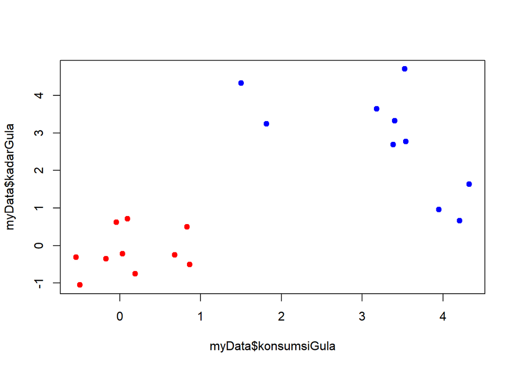

```r
plot(myData$konsumsiGula,myData$kadarGula, col = ifelse(y=="1", "blue", "red"), pch = 19)
```

Dapat kita lihat, data point pada dua kelas di atas cukup terpisah, sehingga dapat dipisahkan secara linear (*linearly separable*).

### **Contoh 1**

Data point-data point di data set `myData` coba kita kelompokkan menggunakan SVM tanpa membagi data menjadi **training data** dan **test data**.

1. Algoritma SVM terlebih dahulu kita ambil dari package **e1071** dengan perintah

```r
library(e1071)
```

Jika package **e1071** tidak ditemukan, install dulu package **e1071** dengan perintah `install.packages("e1071")`. Dokumentasi dari package **e1071** dapat dilihat di **sini**.

2. Membangun model klasifikasi (*training*) untuk data point di `myData` menggunakan SVM dengan memanggil fungsi `svm()`.

```r
modelSVM1 <- svm(Diabetes ~ ., data = myData, kernel = "linear")
```

Parameter pertama, jika berisi suatu `factor`, maka `factor` tersebut akan menjadi acuan dalam membangun model (`fit`). Parameter kedua adalah data yang bertipe data frame dan berisi variabel-variabel yang akan diklasifikasikan. Parameter ketiga untuk mendeskripsikan kernel yang akan digunakan.

3. Untuk melihat hasil pemodelan SVM dapat kita print nilai dari `modelSVM1`

```r
print(modelSVM1)
```

```
##
## Call:
## svm(formula = Diabetes ~ ., data = myData, kernel = "linear")
##
##
## Parameters:
##    SVM-Type:  C-classification
##  SVM-Kernel:  linear
##        cost:  1
##
## Number of Support Vectors:  3
```

Berdasarkan hasil komputasi di atas, terlihat ada 3 support vector yang ditemukan.

4. Hasil pemodelan SVM terhadap data pointnya dan *hyperplane* pemisah antar 2 kelas coba divisualisasikan menggunakan `plot`

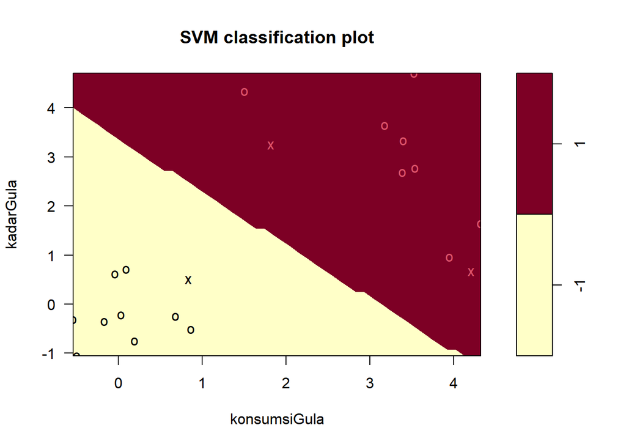

```r
plot(modelSVM1, myData)
```

Pada plot di atas, *support vector* ditunjukkan dengan simbol **“x”** dan data point yang lain dengan simbol **“o”**. Pada plot tersebut warna **merah** pada simbol **“x”** dan simbol **“o”** menunjukkan bahwa dia masuk kelas (**+1**), sedangkan warna **hitam** pada simbol **“x”** dan simbol **“o”** menunjukkan bahwa dia masuk kelas (**-1**). Terlihat, kelas y=(**+1**) memiliki 2 *support vector* dan kelas y=(**-1**) memiliki 1 *support vector*.

### **Contoh 2**

Pada contoh ini, data point-data point di data set `myData` coba kita kelompokkan menggunakan SVM dengan membagi data menjadi **training data** dan **test data**. Pembagian data tersebut menggunakan **cross validation**. Di contoh ini data akan dibagi ke dalam 5 lipatan atau **5-fold cross validation**.

Gambar 1 menunjukkan ilustrasi **5-fold cross validation**. Misal data set kita memiliki 100 data point. Seratus data point tersebut dibagi 5 (karena yang diminta 5 lipatan). Jadi ada 5 lipatan lipatan 1, lipatan 2, lipatan 3, lipatan 4, dan lipatan 5. Masing-masing lipatan berisi 20 data point. Karena ada 5 lipatan, maka akan ada 5 kali *training* juga. Salah satu dari lima lipatan tersebut akan bergantian menjadi **test data** dan sisanya menjadi **training data** di setiap *training*-nya.

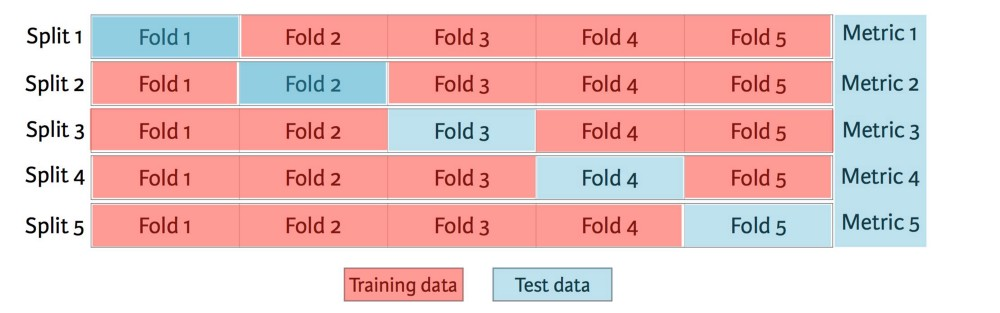

Gambar 1. 5-fold cross validation

1. Package **caret** dipanggil untuk mengambil fungsi `trainControl()` yang akan membantu dalam proses **cross validation**.

```r
library(caret)
```

Jika package **caret** tidak ditemukan, install dulu package **caret** dengan perintah `install.packages("caret")`. Dokumentasi dari package **caret** dapat dilihat di [**sini**](https://www.rdocumentation.org/packages/caret/versions/6.0-86).

2. Sebelum pembagian data point dilakukan, kita `set` dulu `seed`-nya.

```r
set.seed(132)
```

3. Pembagian data menjadi **training data** dan **test data** ke dalam 5 lipatan atau **5-fold cross validation** dengan menggunakan fungsi `trainControl()`

```r
train_control <- trainControl(method="cv", number=5)
```

4. Model klasifikasi untuk data point di `myData` yang telah dibagi ke **training data** dan **test data** dibangun menggunakan SVM. Berbeda dengan sebelumnya, kali ini model dibangun menggunakan fungsi `train()` dari package **caret**.

```r
modelSVM2 <- train(Diabetes ~., data = myData, method = "svmLinear", trControl = train_control)
```

5. Akurasi di setiap *fold* dari proses *training* di atas dilihat dengan

```r
modelSVM2$resample
```

| Accuracy | Kappa | Resample |
| --- | --- | --- |
| 1 | 1 | Fold1 |
| 1 | 1 | Fold2 |
| 1 | 1 | Fold3 |
| 1 | 1 | Fold4 |
| 1 | 1 | Fold5 |

Dari hasil di atas dapat dilihat bahwa akurasi yang dapat dicapai di setiap *fold* adalah 1 (100% benar dalam memprediksi kelas dalam setiap test set).

6. Untuk melihat rata-rata akurasi dan confusion matrix dari model tersebut dijalankan perintah berikut

```r
confusionMatrix(modelSVM2)
```

```
## Cross-Validated (5 fold) Confusion Matrix
##
## (entries are percentual average cell counts across resamples)
##
##           Reference
## Prediction -1  1
##         -1 50  0
##         1   0 50
##
##  Accuracy (average) : 1
```

### **II. When the data are NOT linearly separable**

Kedua, kita akan mencoba SVM pada data dengan **dua kelas** yang tidak dapat dipisahkan secara **linear**. Kali ini, *data set* yang akan digunakan, kita buat sendiri berdasarkan tutorial di [sini](https://www4.stat.ncsu.edu/~reich/BigData/code/SVM.html)).

1. Sebelum bilangan random dibangkitkan, kita `set` dulu `seed`-nya. Tujuannya agar saat bilangan random tersebut kita bangkit lagi di lain waktu, kita mendapatkan bilangan yang sama dengan sebelumnya.

```r
set.seed(143)
```

2. Mendeskripsikan variabel n untuk menyatakan jumlah data point, yaitu 1000

```r
n <- 1000
```

3. Membangkitkan 1000 data secara **random** dan terdistribusi **Uniform** menggunakan fungsi `runif()`. Seribu data random tersebut dibangkitkan 2 kali, sebagai variabel **x1** dan **x2**. Kemudian dua varibel tersebut digabung menjadi 1 matrix menggunakan fungsi `cbind()`.

```r
x <- cbind(runif(n),runif(n))
```

4. Membangkitkan 1000 data lagi secara **random** dan terdistribusi **binomial** untuk variabel **y** atau kelas/label. Seribu data tersebut hanya memiliki nilai (**+1**) dan (**-1**). Kita asumsikan kelas **Diabetes** dengan simbol (**+1**) dan kelas **Tidak Diabetes** dengan simbol (**-1**).

```r
eta  <- x[,2] - sin(10*x[,1])
prob <- 1/(1+exp(-5*eta))
y    <- 2*rbinom(n, 1, prob)-1
y  <- as.factor(y)
```

5. Variabel **x1**, **x2**, dan **y** disatukan ke dalam satu `data frame` dengan nama `myData2`.

```r
myData2 <- data.frame(x,y)
```

6. Setiap kolom dari data frame `myData2` diberi nama.

```r
colnames(myData2) <- c("kadarGula", "konsumsiGula", "Diabetes")
head(myData2)
```

|  | kadarGula | konsumsiGula | Diabetes |
| --- | --- | --- | --- |
| 1 | 0.943225271 | 0.3101158 | 1 |
| 2 | 0.007896937 | 0.1373378 | -1 |
| 3 | 0.741024859 | 0.3609989 | 1 |
| 4 | 0.416615239 | 0.4853952 | 1 |
| 5 | 0.076179760 | 0.5620341 | -1 |
| 6 | 0.951352049 | 0.4127726 | 1 |

7. Plot data set `myData2`. Axis x untuk variabel **x2** atau **konsumsi gula**. Axis y untuk variabel **x1** atau **kadar gula**.. Data point yang termasuk kelas (**+1**) akan diberi warna **biru**. Sedangkan, data point yang termasuk kelas (**-1**) akan diberi warna **merah**

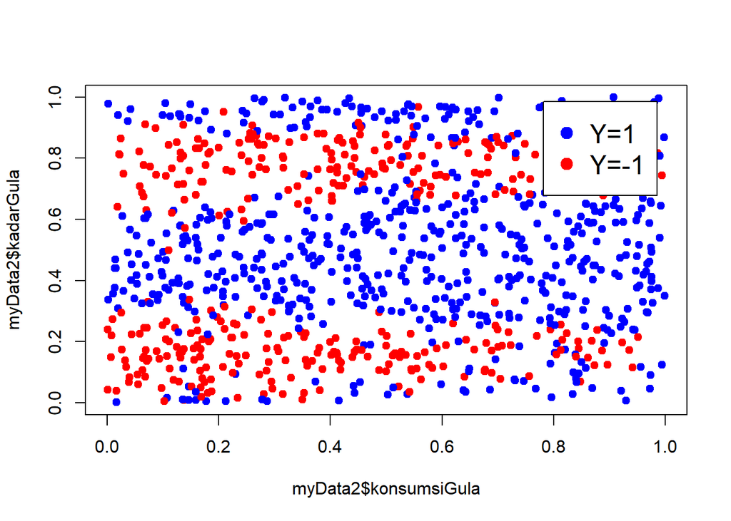

```r
plot(myData2$konsumsiGula,myData2$kadarGula, col = ifelse(y=="1", "blue", "red"), pch = 19)
legend("topright", c("Y=1","Y=-1"),pch=19,col=c("blue", "red"), inset=0.05, bg=gray(1), cex=1.5)
```

Dapat kita lihat, data point pada dua kelas di atas bercampur, sehingga tidak dapat dipisahkan secara linear (*not linearly separable*).

### **Contoh 3**

Pada Contoh 3 ini, kita lakukan langkah yang sama dengan Contoh 1. Bedanya hanya data set yang digunakan pada Contoh 3 adalah `myData2` dan *kernel* yang digunakan pada SVM adalah **radial basis**. 1. Membangun model klasifikasi untuk data point di `myData2` menggunakan SVM

```r
library(e1071)
# set.seed(453)
modelSVM3 <-  svm(Diabetes ~ ., data = myData2, kernel = "radial")
print(modelSVM3)
```

```
##
## Call:
## svm(formula = Diabetes ~ ., data = myData2, kernel = "radial")
##
##
## Parameters:
##    SVM-Type:  C-classification
##  SVM-Kernel:  radial
##        cost:  1
##
## Number of Support Vectors:  524
```

Berdasarkan hasil komputasi di atas, terlihat ada 524 support vector yang ditemukan.

2. Hasil pemodelan SVM terhadap data pointnya dan *hyperplane* pemisah antar 2 kelas coba divisualisasikan menggunakan `plot`

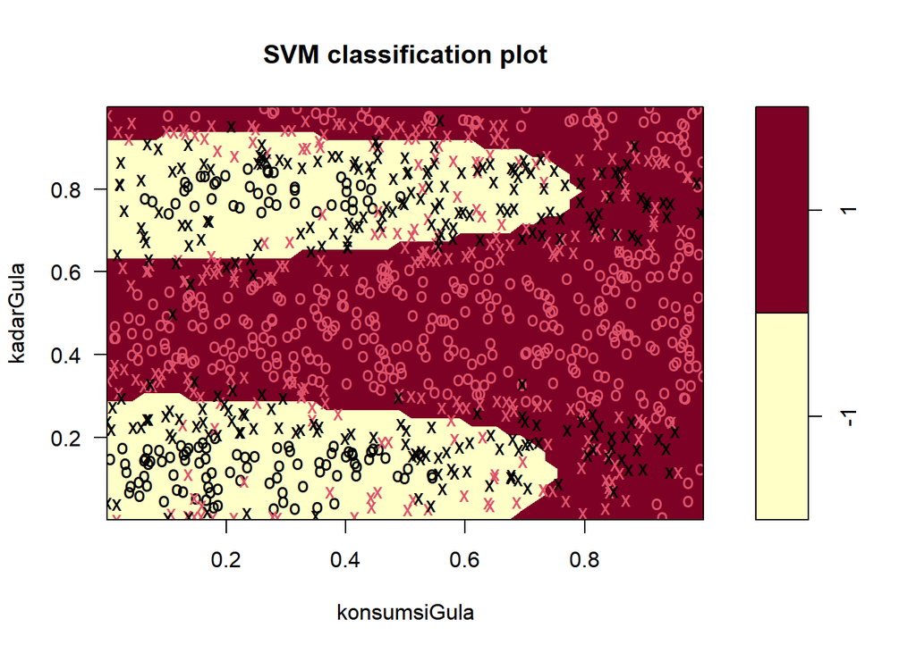

```r
plot(modelSVM3, myData2)
```

Pada plot di atas, *support vector* ditunjukkan dengan simbol **“x”** dan data point yang lain dengan simbol **“o”**. Pada plot tersebut warna **merah** pada simbol **“x”** dan simbol **“o”** menunjukkan bahwa dia masuk kelas (**+1**), sedangkan warna **hitam** pada simbol **“x”** dan simbol **“o”** menunjukkan bahwa dia masuk kelas (**-1**). Terlihat, ada potensi misklasifikasi di plot tersebut.

### **Contoh 4**

Pada Contoh 4 ini, kita lakukan langkah yang sama dengan Contoh 2. Bedanya hanya data set yang digunakan pada Contoh 4 adalah `myData2`, *kernel* yang digunakan pada SVM adalah **radial basis**, dan jumlah lipatan yang pada *cross validation* adalah 10 atau **10-fold cross validation**.

1. Membangun model klasifikasi untuk data point di `myData2` menggunakan SVM

```r
library(caret)
set.seed(543)
train_control2 <- trainControl(method="cv", number=10)
modelSVM4 <- train(Diabetes ~., data = myData2, method = "svmRadial", trControl = train_control2)
modelSVM4$resample
```

| Accuracy | Kappa | Resample |
| --- | --- | --- |
| 0.8181818 | 0.6193934 | Fold02 |
| 0.8316832 | 0.6499490 | Fold01 |
| 0.8217822 | 0.6204593 | Fold04 |
| 0.8100000 | 0.5873154 | Fold03 |
| 0.8700000 | 0.7121346 | Fold06 |
| 0.8888889 | 0.7639280 | Fold05 |
| 0.8700000 | 0.7139085 | Fold08 |
| 0.8400000 | 0.6698308 | Fold07 |
| 0.8400000 | 0.6605855 | Fold10 |
| 0.8300000 | 0.6481788 | Fold09 |

Dari hasil di atas dapat dilihat bahwa akurasi yang dapat dicapai di setiap *fold* sekitar 0.8 (kurang lebih 80% benar dalam memprediksi kelas dalam setiap test set).

2. Untuk melihat rata-rata akurasi dan confusion matrix dari model tersebut dijalankan perintah berikut

```r
confusionMatrix(modelSVM4)
```

```
## Cross-Validated (10 fold) Confusion Matrix
##
## (entries are percentual average cell counts across resamples)
##
##           Reference
## Prediction   -1    1
##         -1 29.9  7.1
##         1   8.7 54.3
##
##  Accuracy (average) : 0.842
```

Dari hasil di atas dapat dilihat bahwa rata-rata akurasi sebesar 0.84. Untuk perhitungan hasil rata-rata TPR, FPR, TNR, FNR dari confusion matrix berdasarkan 10 fold di atas dapat dihitung menggunakan panduan [di sini](https://www.dataschool.io/simple-guide-to-confusion-matrix-terminology/).

~Terima Kasih ~